# WAlMART SALES ANALYSIS

Esther Mordi

2025-01-08

##INTRODUCTION

This analysis explores Walmart sales data, focusing on trends, outliers, and the impact of holiday on sales. Key steps include data exploration, cleaning, visualization and correlation analysis.

##ANALYSIS GOAL

The goals for this analysis are as follows:

- Familiarize with the dataset and it’s structure.
- Perform data cleaning and preparation for analysis.
- Explore and analyze the data to uncover trends, relationship, and insights.
- Data visualization

##DATA SOURCE

The data used in this analysis is sourced from [Kaggle](https://www.kaggle.com/datasets/mikhail1681/walmart-sales).

```r
knitr::opts_chunk$set(echo = TRUE, results = 'markup', fig.show = 'asis')

#Loading libraries
library(tidyverse)

#Importing dataset
walmart_sales <- read_csv("C:/Users/esthe/OneDrive/Documents/PORTFOLIOPROJECTS/walmart_sales.csv")
```

##DATA EXPLORATION and CLEANING

```r
view(walmart_sales)
head(walmart_sales)
```

```
## # A tibble: 6 × 8
##   Store Date       Weekly_Sales Holiday_Flag Temperature Fuel_Price   CPI
##   <dbl> <chr>             <dbl>        <dbl>       <dbl>      <dbl> <dbl>
## 1     1 5/2/2010       1643691.            0        42.3       2.57  211.
## 2     1 12/2/2010      1641957.            1        38.5       2.55  211.
## 3     1 19-02-2010     1611968.            0        39.9       2.51  211.
## 4     1 26-02-2010     1409728.            0        46.6       2.56  211.
## 5     1 5/3/2010       1554807.            0        46.5       2.62  211.
## 6     1 12/3/2010      1439542.            0        57.8       2.67  211.
## # ℹ 1 more variable: Unemployment <dbl>
```

```r
str(walmart_sales)
```

```
## spc_tbl_ [6,435 × 8] (S3: spec_tbl_df/tbl_df/tbl/data.frame)
##  $ Store       : num [1:6435] 1 1 1 1 1 1 1 1 1 1 ...
##  $ Date        : chr [1:6435] "5/2/2010" "12/2/2010" "19-02-2010" "26-02-2010" ...
##  $ Weekly_Sales: num [1:6435] 1643691 1641957 1611968 1409728 1554807 ...
##  $ Holiday_Flag: num [1:6435] 0 1 0 0 0 0 0 0 0 0 ...
##  $ Temperature : num [1:6435] 42.3 38.5 39.9 46.6 46.5 ...
##  $ Fuel_Price  : num [1:6435] 2.57 2.55 2.51 2.56 2.62 ...
##  $ CPI         : num [1:6435] 211 211 211 211 211 ...
##  $ Unemployment: num [1:6435] 8.11 8.11 8.11 8.11 8.11 ...
##  - attr(*, "spec")=
##   .. cols(
##   ..   Store = col_double(),
##   ..   Date = col_character(),
##   ..   Weekly_Sales = col_double(),
##   ..   Holiday_Flag = col_double(),
##   ..   Temperature = col_double(),
##   ..   Fuel_Price = col_double(),
##   ..   CPI = col_double(),
##   ..   Unemployment = col_double()
##   .. )
##  - attr(*, "problems")=<externalptr>
```

```r
summary(walmart_sales)
```

```
##      Store        Date            Weekly_Sales      Holiday_Flag
##  Min.   : 1   Length:6435        Min.   : 209986   Min.   :0.00000
##  1st Qu.:12   Class :character   1st Qu.: 553350   1st Qu.:0.00000
##  Median :23   Mode  :character   Median : 960746   Median :0.00000
##  Mean   :23                      Mean   :1046965   Mean   :0.06993
##  3rd Qu.:34                      3rd Qu.:1420159   3rd Qu.:0.00000
##  Max.   :45                      Max.   :3818686   Max.   :1.00000
##   Temperature       Fuel_Price         CPI         Unemployment
##  Min.   : -2.06   Min.   :2.472   Min.   :126.1   Min.   : 3.879
##  1st Qu.: 47.46   1st Qu.:2.933   1st Qu.:131.7   1st Qu.: 6.891
##  Median : 62.67   Median :3.445   Median :182.6   Median : 7.874
##  Mean   : 60.66   Mean   :3.359   Mean   :171.6   Mean   : 7.999
##  3rd Qu.: 74.94   3rd Qu.:3.735   3rd Qu.:212.7   3rd Qu.: 8.622
##  Max.   :100.14   Max.   :4.468   Max.   :227.2   Max.   :14.313
```

```r
#checking for missing values
sum(is.na(walmart_sales))
```

```
## [1] 0
```

```r
#converting Holiday_Flag to a factor
walmart_sales$Holiday_Flag <- as.factor(walmart_sales$Holiday_Flag)
class(walmart_sales$Holiday_Flag)
```

```
## [1] "factor"
```

```r
#correcting date inconsistency
walmart_sales$Date <- gsub("-", "/", walmart_sales$Date)
walmart_sales$Date <- as.Date(walmart_sales$Date, format="%d/%m/%Y")
sum(is.na(walmart_sales$Date))
```

```
## [1] 0
```

```r
view(walmart_sales$Date)
head(walmart_sales$Date)
```

```
## [1] "2010-02-05" "2010-02-12" "2010-02-19" "2010-02-26" "2010-03-05"
## [6] "2010-03-12"
```

```r
#checking for duplicates
duplicates <- walmart_sales[duplicated(walmart_sales), ]
duplicates
```

```
## # A tibble: 0 × 8
## # ℹ 8 variables: Store <dbl>, Date <date>, Weekly_Sales <dbl>,
## #   Holiday_Flag <fct>, Temperature <dbl>, Fuel_Price <dbl>, CPI <dbl>,
## #   Unemployment <dbl>
```

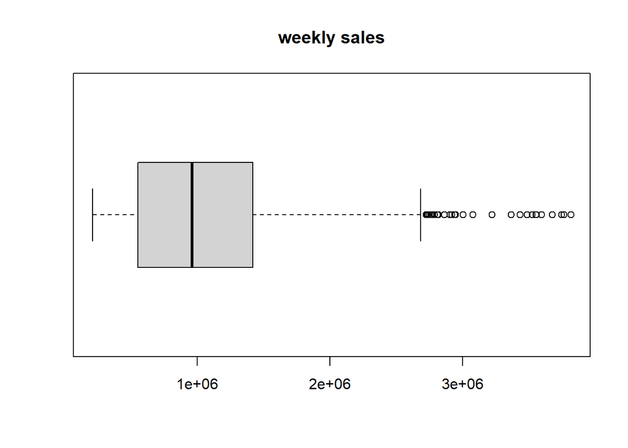

```r
#checking for outliers
boxplot(walmart_sales$Weekly_Sales, main = "weekly sales", horizontal = TRUE)
```

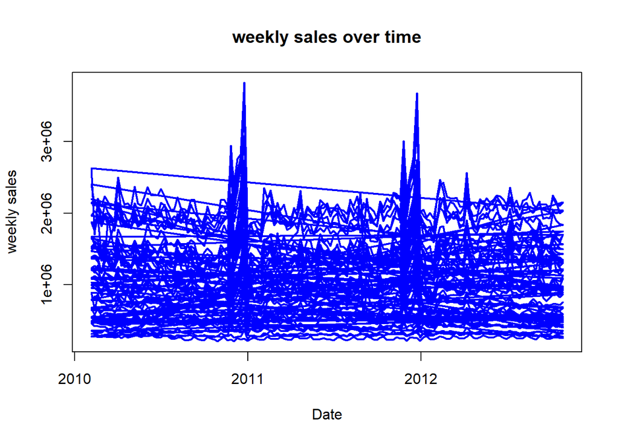

```r
plot(walmart_sales$Date, walmart_sales$Weekly_Sales,
     type = "l",
     main = "weekly sales over time",
     xlab = "Date",
     ylab = "weekly sales",
     col = "blue",
     lwd = 2)
```

```r
#The boxplot shows that there is a significant number of outliers on the higher end of weekly sales (above the upper whisker). These outliers indicate a few weeks where sales were significantly high compared to the rest of the data. The majority of the data lies within the interquartile range, but the right side spread reveals extreme values that's further analysed below.

#investigating outliers
max_sales <- max(walmart_sales$Weekly_Sales)
outlier_date <- walmart_sales$Date[walmart_sales$Weekly_Sales == max_sales] #max sales and corresponding date
print(paste("The highest Weekly Sales are:", max_sales, "on", outlier_date))
```

```
## [1] "The highest Weekly Sales are: 3818686.45 on 2010-12-24"
```

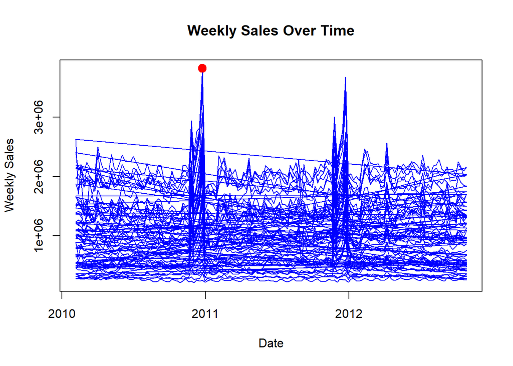

```r
#plot with the outlier highlighted
plot(walmart_sales$Date, walmart_sales$Weekly_Sales,
     type = "l",
     main = "Weekly Sales Over Time",
     xlab = "Date",
     ylab = "Weekly Sales",
     col = "blue")

points(outlier_date, max_sales,
       col = "red",
       pch = 19,
       cex = 1.5)
```

```r
#The chart above shows that the highlighted outlier corresponds to a sharp and isolated spike in weekly sales towards the end of the year 2010 and another spike is also seen toward the end of the year 2011, further analysis shows us the specific outlier date with maximum sales to be 2010-12-24, a day to Christmas. so, it's safe to conclude that spike in sales was caused by an holiday shopping factor which means this outlier is crucial to our analysis and so it was kept.
```

##BASIC ANALYSIS

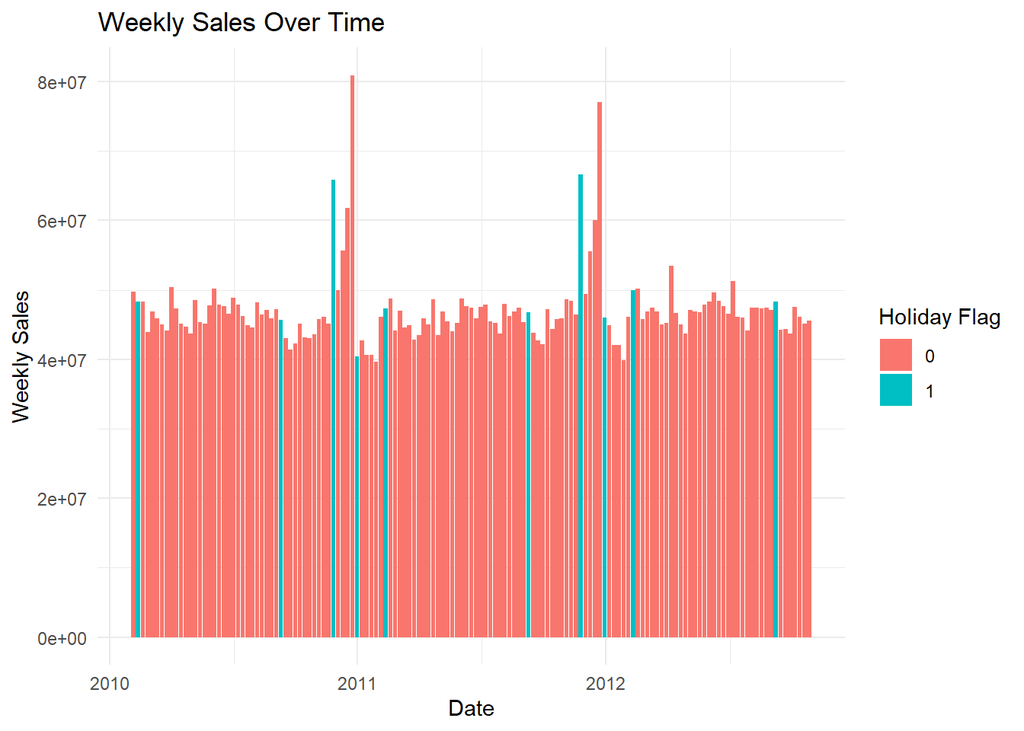

```r
#sales trends by the year
ggplot(walmart_sales, aes(x = Date, y = Weekly_Sales, fill = factor(Holiday_Flag))) +
  geom_col() +
  labs(
    title = "Weekly Sales Over Time",
    x = "Date",
    y = "Weekly Sales",
    fill = "Holiday Flag"
  ) +
  theme_minimal()
```

```r
#Average sales by month
walmart_sales$Month <- format(walmart_sales$Date, "%m")

avg_sales_by_month <- aggregate(Weekly_Sales ~ Month, data = walmart_sales, FUN = mean)
print(avg_sales_by_month)
```

```
##    Month Weekly_Sales
## 1     01     923884.6
## 2     02    1053199.8
## 3     03    1013309.2
## 4     04    1026761.6
## 5     05    1031714.0
## 6     06    1064324.6
## 7     07    1031747.6
## 8     08    1048017.5
## 9     09     989335.3
## 10    10     999632.1
## 11    11    1147265.9
## 12    12    1281863.6
```

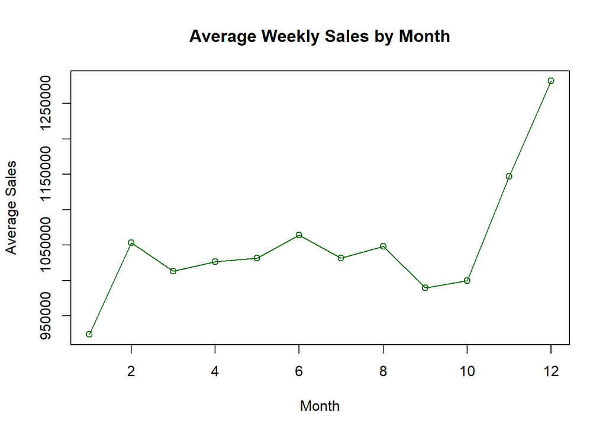

```r
plot(as.numeric(avg_sales_by_month$Month), avg_sales_by_month$Weekly_Sales,
     type = "o",
     col = "darkgreen",
     main = "Average Weekly Sales by Month",
     xlab = "Month",
     ylab = "Average Sales")
```

```r
#Impact of Holidays on sales
avg_sales <- aggregate(Weekly_Sales ~ Holiday_Flag, data = walmart_sales, FUN = mean)
print(avg_sales)
```

```
##   Holiday_Flag Weekly_Sales
## 1            0      1041256
## 2            1      1122888
```

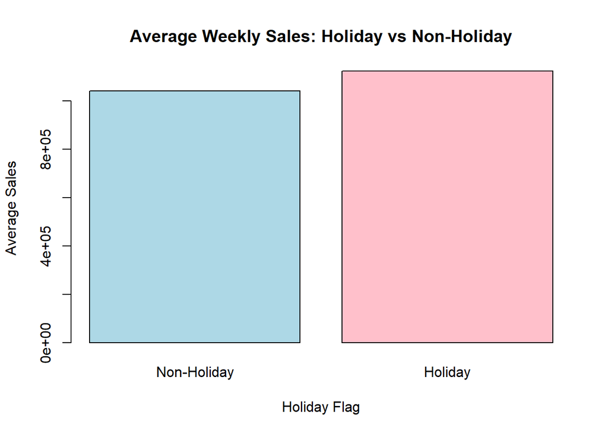

```r
barplot(avg_sales$Weekly_Sales,
        names.arg = c("Non-Holiday", "Holiday"),
        col = c("lightblue", "pink"),
        main = "Average Weekly Sales: Holiday vs Non-Holiday",
        xlab = "Holiday Flag",
        ylab = "Average Sales")
```

```r
#Correlation Analysis

library(knitr)

correlation_matrix <- cor(walmart_sales[, c("Weekly_Sales", "Temperature", "Fuel_Price", "CPI", "Unemployment")])
kable(correlation_matrix, caption = "Correlation Matrix of Walmart Sales Data")
```

Correlation Matrix of Walmart Sales Data

|  | Weekly_Sales | Temperature | Fuel_Price | CPI | Unemployment |
| --- | --- | --- | --- | --- | --- |
| Weekly_Sales | 1.0000000 | -0.0638100 | 0.0094638 | -0.0726342 | -0.1061761 |
| Temperature | -0.0638100 | 1.0000000 | 0.1449818 | 0.1768877 | 0.1011579 |
| Fuel_Price | 0.0094638 | 0.1449818 | 1.0000000 | -0.1706418 | -0.0346837 |
| CPI | -0.0726342 | 0.1768877 | -0.1706418 | 1.0000000 | -0.3020201 |
| Unemployment | -0.1061761 | 0.1011579 | -0.0346837 | -0.3020201 | 1.0000000 |

```r
#Most correlation are weak, suggesting that no variable strongly influences another. The only significant correlation is between CPI and Unemployment which have a moderately negative relationship, suggesting that when Unemployment decreases, CPI tends to increase and vise-versa.

#Weekly sales appears to be weakly influenced by all variables, meaning there might not be strong external predictors for sales, or the relationship might be non-linear.
```

##CONCLUSION

#Recommendations

- **Leverage holidays:** To capitalize on the holiday season, the business should focus on targeted marketing campaigns, discounts, and promotions leading up to major holidays. Proper inventory and staffing management will ensure smooth operations during these peak periods.
- **Boost off-peak sales:** Introduce loyalty programs, flash sales, or mid-year promotions to increase non-holiday sales. Consider creating new events or themes for non-peak periods.
- **Plan seasonally:** Offering seasonal or limited-edition products can help capture consumer interest and maximize holiday sales. Also, tailor inventory to high-performing items during key periods.
- **Adopt data-driven strategies:** Regularly analyze sales trends and customer behavior to identify new opportunities and personalize marketing efforts.
- **Diversify revenue streams:** In the long term, diversifying product offerings and expanding into e-commerce channels can help reduce reliance on holiday sales and create opportunities for sustained growth.